# Sacramento River

Sadie Gill, Mark Tompkins

July 2020

## Future Data Improvement

None planned.

## Instream Spawning Habitat

**Data Source:** [FWS 2003](https://dsm-docs.s3.us-west-2.amazonaws.com/Sacramento_River_Spawning_Final_Report_Feb_4_2003.pdf) (pg 29-31)

Spawning habitat areas for Chinook Salmon (Fall Run, Late Fall Run, Winter Run) and Steelhead are based on data from a US Fish and Wildlife Service 2003 study of spawning habitat in the Sacramento River, between Keswick Dam and the confluence with Battle Creek. The spawning weighted usable area (WUA) source data were developed in six study segments. One of the study segments considers conditions with and without the Anderson Cottonwood Irrigation District (A.C.I.D.) diversion dam. The A.C.I.D. boards are April 1st - October 31st. The Upper Sacramento Fall Run spawning WUA values include the spawning that occurs in the river section from Keswick to Deer Creek. The Late-Fall Run, Winter Run, and Steelhead spawn from Keswick to Battle Creek. Within the life cycle model, spawning only occurs on the Sacramento River in the Upper Sacramento River reach. This habitat area includes the area of both the Upper Sacramento River and Upper Mid-Sacramento River reaches combined. Mark Gard from the California Department of Fish and Wildlife provided the data in the ‘Sacramento’ tab of this [spreadsheet](https://cvpiahabitat-r-package.s3-us-west-2.amazonaws.com/IFIMWUA.xlsx). The data have been reorganized for clarity and are stored with this data package.

### Spawning WUA

Below are the instream spawning WUAs for Fall Run Chinook Salmon, Late Fall Run Chinook Salmon, Winter Run Chinook Salmon, and Steelhead in the Sacramento River. Units are in square feet per 1000 feet.

#### Spawning Habitat (A.C.I.D boards in)

Header Descriptions: flow_cfs = flow in cubic feet per second, FR_spawn_wua = Fall Run Chinook Spawning WUA, LFR_spawning_wua = Late Fall Run Chinook Spawning WUA, ST_spawn_wua = Steelhead Spawning WUA, WR_spawn_wua = Winter Run Chinook Spawning WUA, watershed = section of stream modeled for CVPIA SDM

| flow_cfs | FR_spawn_WUA | LFR_spawn_WUA | ST_spawn_WUA | WR_spawn_WUA | watershed |
| --- | --- | --- | --- | --- | --- |
| 3250 | 8553.719 | 7945.461 | 1998.007 | 5321.020 | Upper Sacramento River |
| 3500 | 8756.922 | 8204.024 | 2034.904 | 5627.105 | Upper Sacramento River |
| 3750 | 8939.986 | 8329.719 | 2041.319 | 5880.905 | Upper Sacramento River |
| 4000 | 9069.236 | 8394.523 | 2025.323 | 6111.320 | Upper Sacramento River |
| 4250 | 9082.162 | 8429.446 | 2009.004 | 6350.286 | Upper Sacramento River |

*… with 25 more rows*

#### Spawning Habitat (A.C.I.D boards out)

Header Descriptions: flow_cfs = flow in cubic feet per second, FR_spawn_wua = Fall Run Chinook Spawning WUA, LFR_spawning_wua = Late Fall Run Chinook Spawning WUA, ST_spawn_wua = Steelhead Spawning WUA, WR_spawn_wua = Winter Run Chinook Spawning WUA, watershed = section of stream modeled for CVPIA SDM

| flow_cfs | FR_spawn_WUA | LFR_spawn_WUA | ST_spawn_WUA | WR_spawn_WUA | watershed |
| --- | --- | --- | --- | --- | --- |
| 3250 | 8679.536 | 8426.900 | 1685.370 | 6987.003 | Upper Sacramento River |
| 3500 | 8818.288 | 8558.582 | 1730.260 | 7311.780 | Upper Sacramento River |
| 3750 | 8939.287 | 8562.543 | 1748.125 | 7569.374 | Upper Sacramento River |
| 4000 | 9007.222 | 8508.830 | 1746.330 | 7789.940 | Upper Sacramento River |
| 4250 | 8966.538 | 8439.785 | 1741.729 | 8004.645 | Upper Sacramento River |

*… with 25 more rows*

The following plot shows the spawning WUA in square feet per thousand feet for Fall Run Chinook, Late-fall Run Chinook, Winter Run Chinook, and Steelhead. These area per length rates are multiplied by the total spawning reach length mapped by the Science Integration Team (SIT) to estimate available habitat.

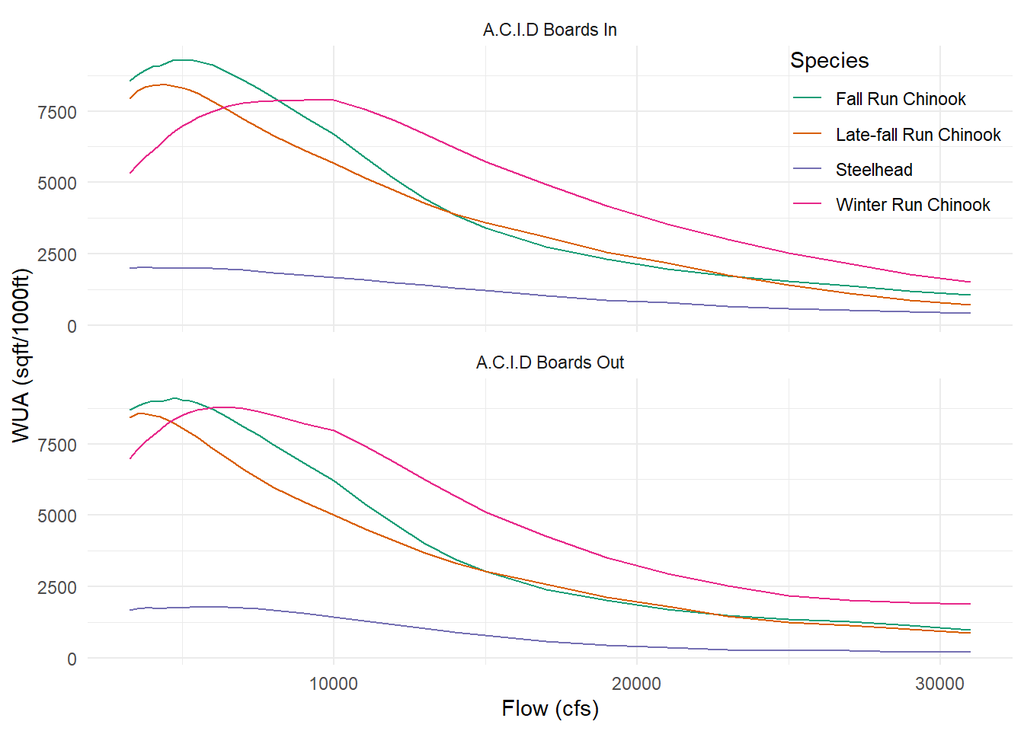

## Instream and Floodplain Rearing Habitat

**Data Source:** Central Valley Floodplain Evaluation and Delineation (CVFED) HEC-RAS hydraulic model refined for use in the [NOAA-NMFS Winter Run Chinook Salmon life cycle model](https://cvpiahabitat-r-package.s3-us-west-2.amazonaws.com/2017Hendrix.pdf)

Instream and floodplain rearing habitat areas are based on habitat modeling conducted by NOAA NMFS for their Winter Run Chinook Salmon life cycle model. The entire mapped rearing extent of the Sacramento River was modeled using the Central Valley Floodplain Evaluation and Delineation (CVFED) HEC-RAS hydraulic model, refined for use in their Winter Run Chinook Salmon life cycle model. NOAA NMFS provided tabular suitable rearing habitat area data for three reaches of the Sacramento River (Keswick to Battle Creek, Battle Creek to Feather River, and Feather River to Freeport). The high quality depth and high quality velocity criteria (“Pref11”) “ChanArea” value was used for instream habitat, and “BankArea” result was used as floodplain area.

High quality habitat defined by:

- Channel depth > 0.2 m and < 1.5 m
- Velocity <= 0.15 m/s

The habitat areas are suitable and do not require futher suitability scaling.

NOAA NMFS Winter Run Chinook Salmon Life Cycle Model Segments:

- Section 1 - Keswick to Battle Creek (28.92 mi)
- Section 2 - Battle Creek to Feather River (186.50 mi)
- Section 3 - Feather River to Freeport (33.90 mi)

CVPIA Sacramento Rearing Segments:

- Upper Sacramento River - Keswick to Red Bluff (59.28 mi) falls within Section 1 and Section 2 of NOAA NMFS modeling
- Upper-mid Sacramento River - Red Bluff to Wilkins Slough (122.25 mi) falls within Section 2 of NOAA NMFS modeling
- Lower-mid Sacramento River - Wilkins Slough to American (57.96 mi) falls within Section 2 and Section 3 of NOAA NMFS modeling
- Lower Sacramento River - American to Freeport (13.70 mi) falls within Section 3 of NOAA NMFS modeling

### Rearing Habitat Area

The juvenile instream high quality rearing habitat for Winter Run Chinook Salmon in the Sacramento River is used as a surrogate for the other present Chinook runs. Units are in square meters.

| Flow (cfs) | Upper Sacramento River | Upper-mid Sacramento River | Lower-mid Sacramento River | Lower Sacramento River |
| --- | --- | --- | --- | --- |
| 2000 | 408108.4 | 878413.6 | 588830.0 | 141024.84 |
| 2500 | 328336.6 | 741025.1 | 511765.5 | 125106.62 |
| 3000 | 300066.5 | 651171.6 | 433134.1 | 103166.84 |
| 3500 | 256124.3 | 534196.4 | 370989.6 | 91030.76 |
| 4000 | 296282.6 | 509043.3 | 333820.6 | 78698.88 |

*… with 76 more rows*

#### Chinook Salmon Instream Rearing Area Plot

The following plot shows the flow to highly suitable area in acres for Chinook Salmon Juveniles.

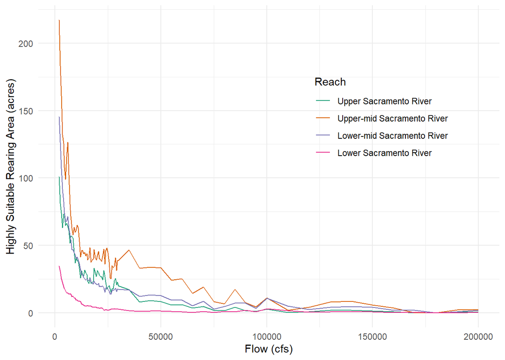

## Floodplain Data

The areas represent highly suitable rearing area in square meters.

#### Upper, Upper-mid, and Lower-mid Sacramento River Floodplain Rearing Data

| Flow (cfs) | Upper Sacramento River | Upper-mid Sacramento River | Lower-mid Sacramento River |
| --- | --- | --- | --- |
| 3500 | 0.0000 | 0.0000 | 0.0000 |
| 4000 | 6530.6297 | 26296.7549 | 7289.9552 |
| 4500 | 8071.5648 | 32501.6072 | 9010.0570 |
| 5000 | 131.9869 | 531.4688 | 147.3332 |
| 5500 | 135.3470 | 544.9990 | 151.0840 |

*… with 73 more rows*

#### Lower Sacramento River Floodplain Rearing Data

The Lower Sacramento River floodplain data are shown below in a separate table because floodplain is activated at a higher threshold (27500 cfs) than the other Sacramento sections. The areas represent highly suitable rearing area in square meters.

| Flow (cfs) | Lower Sacramento River |
| --- | --- |
| 27500 | 0.0000 |
| 28000 | 119.9870 |
| 28500 | 135.5557 |
| 29000 | 151.1244 |
| 29500 | 252.4457 |

*… with 25 more rows*

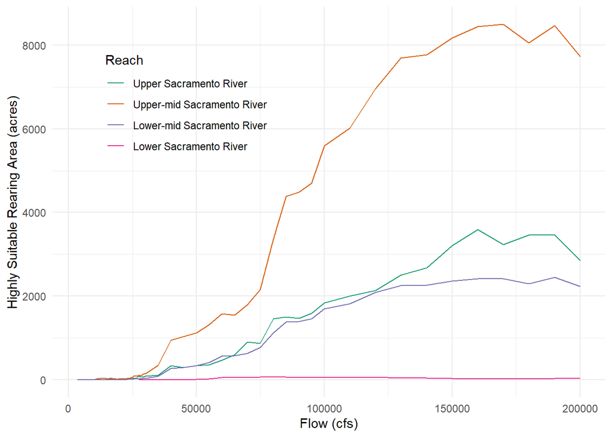